# CINNA

Minoo Ashtiani, Mehdi Mirzaie, Mohieddin Jafari

2023-08-08

## 1 Introduction

`CINNA` is an R package submitted on CRAN repository which has been written for centrality analysis in network science. It can be useful for assembling, comparing, evaluating and visualizing several types of centrality measures. This document is an introduction to the usage of this package and includes some user interface examples.

Centrality is defined as a measure for identifying the most important vertices within a network in graph theory. Several centrality types have been provided to compute central nodes by different formulas, while some analysis are needed to evaluate the most informative ones. In this package, we have prepared these resolutions and some examples of real networks.

For the examples in the following sections, we assume that the `CINNA` package has been properly installed into the R environment. This can be done by typing

```r
install.packages("CINNA")
```

```r
library(CINNA)
```

## 2 Some real network examples

We collected five graphs instances based on factual datasets and natural networks. In order to develop some instructions for using this package, we prepared you a brief introduction about the topological of these networks as is described below:

| Name | Type | Description | Nodes | Edges | References |
| --- | --- | --- | --- | --- | --- |
| zachary | unweighted, undirected | friendships between members of a club | 34 | 78 | (Zachary 1977) |
| cortex | unweighted, directed | pathways among cortical region in Macaque | 30 | 311 | (Felleman and Van Essen 1991) |
| kangaroo | weighted, undirected | interactions between kangaroos | 17 | 90 | (KONECT October 2016) |
| rhesus | weighted, directed | grooming occurred among monkeys of an area | 16 | 110 | (KONECT October 2016) |
| drugTarget | bipartite,directed | interactions among drugs and their protein targets | 1599 | 3766 | (Barneh, Jafari, and Mirzaie 2015) |

### 2.1 Undirected & unweighted network

`zachary`(Zachary 1977) is an example of undirected and unweighted network in this package. This data set illustrates friendships between members of a university karate club. It is based on a faction membership after a social portion. The summary of important properties of this network is described below:

Edge Type: Friendship

Node Type: People

Avg Edges: 77.50

Avg Nodes: 34.00

Graph properties: Unweighted, Undirected

This data set can be easily accessed by using data() function:

```r
data("zachary")
zachary
```

```
## IGRAPH 455c916 U--- 34 78 --
## + attr: id (v/n)
## + edges from 455c916:
##  [1]  1-- 2  1-- 3  2-- 3  1-- 4  2-- 4  3-- 4  1-- 5  1-- 6  1-- 7  5-- 7
## [11]  6-- 7  1-- 8  2-- 8  3-- 8  4-- 8  1-- 9  3-- 9  3--10  1--11  5--11
## [21]  6--11  1--12  1--13  4--13  1--14  2--14  3--14  4--14  6--17  7--17
## [31]  1--18  2--18  1--20  2--20  1--22  2--22 24--26 25--26  3--28 24--28
## [41] 25--28  3--29 24--30 27--30  2--31  9--31  1--32 25--32 26--32 29--32
## [51]  3--33  9--33 15--33 16--33 19--33 21--33 23--33 24--33 30--33 31--33
## [61] 32--33  9--34 10--34 14--34 15--34 16--34 19--34 20--34 21--34 23--34
## [71] 24--34 27--34 28--34 29--34 30--34 31--34 32--34 33--34
```

The result would have a class of “igraph” object.

### 2.2 Undirected & weighted network

`kangaroo`(KONECT October 2016) is a sample of undirected and weighted network which indicates interactions among free-ranging grey kangaroos. The edge between two nodes shows a dominance interaction between two kangaroos. The positive weight of each edge represents number of interaction between them. A brief explanation of it’s properties is clarified below:

Edge Type: Interaction

Node Type: Kangaroo

Avg Edges: 91

Nodes: 17

Graph properties: Weighted, Undirected

Edge weights: Positive weights

### 2.3 Directed & unweighted network

`cortex`(Felleman and Van Essen 1991) is a sample of macaque visual cortex network which is collected in 1991. In this data set, vertices represents neocortical areas which involved in visual functions in Macaques. The direction displays the progress of synapses from one to another. A summary of this can be as follows:

Edge Type: Pathway

Node Type: Cortical region

Avg Edges: 315.50

Graph properties: Directed, Unweighted

Edge weights: Positive weights

### 2.4 Directed & weighted network

`rhesus`(KONECT October 2016) is a directed and weighted network which describes grooming between free ranging rhesus macaques (Macaca mulatta) in Cayo Santiago during a two month period in 1963. In this data set a vertex is identified as a monkey and the directed edge among them means grooming between them. The weights of the edges demonstrates how often this manner happened. The network summary is as follows:

Edge Type: Grooming

Node Type: Monkey

Avg Edges: 111

Nodes: 16

Graph properties: Directed, Weighted

Edge weights: Positive weights

### 2.5 Bipartite & directed network

`drugTarget`(Barneh, Jafari, and Mirzaie 2015) is a bipartite, unconnected and directed network demonstrating interactions among Food and Drug Administration (FDA)-approved drugs and their corresponding protein targets. This network is a shrunken one in which metabolizing enzymes, carriers and transporters associated with drug metabolism are filtered and solely targets directly related to their pharmacological effects are included. A summary of this can be like:

Edge Type: interaction

Node Type: drug, protein target

Avg Edges: 3766

Nodes: 1599

Graph properties: Bipartite, unconnected, directed

## 3 Network component analysis

In order to apply several centrality analysis, it is recommended to have a connected graph. Therefore, approaching the connected components of a network is needed. In order to extract components of a graph and use them for centrality analysis, we prepared some functions as below.

### 3.1 The segregation of “igraph” and “network” objects

“graph.extract.components” function is able to read `igraph` and `network` objects and returns their components as a list of `igraph` objects. This function also has this ability to recognized bipartite graphs and user can decide that which project is suitable for his analysis. In order to use this function, we use zachary data set and develop it in all of our functions.

```r
graph_extract_components(zachary)
```

```
## [[1]]
## IGRAPH ec8c272 U--- 34 78 --
## + attr: id (v/n)
## + edges from ec8c272:
##  [1]  1-- 2  1-- 3  2-- 3  1-- 4  2-- 4  3-- 4  1-- 5  1-- 6  1-- 7  5-- 7
## [11]  6-- 7  1-- 8  2-- 8  3-- 8  4-- 8  1-- 9  3-- 9  3--10  1--11  5--11
## [21]  6--11  1--12  1--13  4--13  1--14  2--14  3--14  4--14  6--17  7--17
## [31]  1--18  2--18  1--20  2--20  1--22  2--22 24--26 25--26  3--28 24--28
## [41] 25--28  3--29 24--30 27--30  2--31  9--31  1--32 25--32 26--32 29--32
## [51]  3--33  9--33 15--33 16--33 19--33 21--33 23--33 24--33 30--33 31--33
## [61] 32--33  9--34 10--34 14--34 15--34 16--34 19--34 20--34 21--34 23--34
## [71] 24--34 27--34 28--34 29--34 30--34 31--34 32--34 33--34
```

This results the only component of the zachary graph. This function is also applicable for bipartite networks. Using the `num_proj` argument, user can decide on which projection is interested to work on. As an example of bipartite graphs, we use `drugTarget` network as follows:

```r
data("drugTarget")

drug_comp <- graph_extract_components( drugTarget, directed = TRUE, bipartite_proj = TRUE, num_proj = 1)
```

```
## This graph was created by an old(er) igraph version.
##   Call upgrade_graph() on it to use with the current igraph version
##   For now we convert it on the fly...
```

```r
head(drug_comp)
```

```
## [[1]]
## IGRAPH 4bbc7bd UNW- 11 55 --
## + attr: id (v/n), name (v/c), weight (e/n)
## + edges from 4bbc7bd (vertex names):
##  [1] Abacavir     --Delavirdine   Abacavir     --Didanosine
##  [3] Delavirdine  --Didanosine    Abacavir     --Efavirenz
##  [5] Delavirdine  --Efavirenz     Didanosine   --Efavirenz
##  [7] Abacavir     --Emtricitabine Delavirdine  --Emtricitabine
##  [9] Didanosine   --Emtricitabine Efavirenz    --Emtricitabine
## [11] Abacavir     --Lamivudine    Delavirdine  --Lamivudine
## [13] Didanosine   --Lamivudine    Efavirenz    --Lamivudine
## [15] Emtricitabine--Lamivudine    Abacavir     --Nevirapine
## + ... omitted several edges
##
## [[2]]
## IGRAPH 44a112b UNW- 5 10 --
## + attr: id (v/n), name (v/c), weight (e/n)
## + edges from 44a112b (vertex names):
##  [1] Abarelix   --Ganirelix   Abarelix   --Gonadorelin Ganirelix  --Gonadorelin
##  [4] Abarelix   --Leuprolide  Ganirelix  --Leuprolide  Gonadorelin--Leuprolide
##  [7] Abarelix   --Nafarelin   Ganirelix  --Nafarelin   Gonadorelin--Nafarelin
## [10] Leuprolide --Nafarelin
##
## [[3]]
## IGRAPH 47aba7c UNW- 3 3 --
## + attr: id (v/n), name (v/c), weight (e/n)
## + edges from 47aba7c (vertex names):
## [1] Abciximab   --Eptifibatide Abciximab   --Tirofiban
## [3] Eptifibatide--Tirofiban
##
## [[4]]
## IGRAPH 8aba1fe UNW- 482 8179 --
## + attr: id (v/n), name (v/c), weight (e/n)
## + edges from 8aba1fe (vertex names):
##  [1] Acamprosate   --Alprazolam    Adinazolam    --Alprazolam
##  [3] Acebutolol    --Alprenolol    Albuterol     --Alprenolol
##  [5] Acetophenazine--Amantadine    Acebutolol    --Amiodarone
##  [7] Alfuzosin     --Amiodarone    Alprenolol    --Amiodarone
##  [9] Acetazolamide --Amlodipine    Amitriptyline --Amoxapine
## [11] Alfuzosin     --Amphetamine   Amiodarone    --Amphetamine
```

[output cut: 9 more lines]

```
## [4] Bentiromide--Orlistat
##
## [[6]]
## IGRAPH 326a4ae UNW- 34 522 --
## + attr: id (v/n), name (v/c), weight (e/n)
## + edges from 326a4ae (vertex names):
##  [1] Acetaminophen--Aspirin     Acetaminophen--Balsalazide
##  [3] Aspirin      --Balsalazide Acetaminophen--Bromfenac
##  [5] Aspirin      --Bromfenac   Balsalazide  --Bromfenac
##  [7] Acetaminophen--Carprofen   Aspirin      --Carprofen
##  [9] Balsalazide  --Carprofen   Bromfenac    --Carprofen
## [11] Acetaminophen--Celecoxib   Aspirin      --Celecoxib
## [13] Balsalazide  --Celecoxib   Bromfenac    --Celecoxib
## [15] Carprofen    --Celecoxib   Acetaminophen--Ciclopirox
## + ... omitted several edges
```

### 3.2 The segregation of other graph formats

If you had an edge list, an adjacency matrix or a grapnel format of a network, the `misc_extract_components` can be useful. This function extracts the components of other formats of graph. For illustration, we convert `zachary` graph to an edge list to be able to use it for this function.

```r
library(igraph)
zachary_edgelist <- as_edgelist(zachary)

misc_extract_components(zachary_edgelist)
```

```
## [[1]]
## IGRAPH 9e7ebc0 D--- 34 78 --
## + edges from 9e7ebc0:
##  [1]  1-> 2  1-> 3  2-> 3  1-> 4  2-> 4  3-> 4  1-> 5  1-> 6  1-> 7  5-> 7
## [11]  6-> 7  1-> 8  2-> 8  3-> 8  4-> 8  1-> 9  3-> 9  3->10  1->11  5->11
## [21]  6->11  1->12  1->13  4->13  1->14  2->14  3->14  4->14  6->17  7->17
## [31]  1->18  2->18  1->20  2->20  1->22  2->22 24->26 25->26  3->28 24->28
## [41] 25->28  3->29 24->30 27->30  2->31  9->31  1->32 25->32 26->32 29->32
## [51]  3->33  9->33 15->33 16->33 19->33 21->33 23->33 24->33 30->33 31->33
## [61] 32->33  9->34 10->34 14->34 15->34 16->34 19->34 20->34 21->34 23->34
## [71] 24->34 27->34 28->34 29->34 30->34 31->34 32->34 33->34
```

### 3.3 Giant component extraction

In the most of research topics of network analysis, network features are related to the largest connected component of a graph(Newman 2010). In order to get that for an `igraph` or a `network` object, `giant_component_extract` function is specified. For using this function we can do:

```r
giant_component_extract(zachary)
```

```
## [[1]]
## IGRAPH ddc362d U--- 34 78 --
## + attr: id (v/n)
## + edges from ddc362d:
##  [1]  1-- 2  1-- 3  2-- 3  1-- 4  2-- 4  3-- 4  1-- 5  1-- 6  1-- 7  5-- 7
## [11]  6-- 7  1-- 8  2-- 8  3-- 8  4-- 8  1-- 9  3-- 9  3--10  1--11  5--11
## [21]  6--11  1--12  1--13  4--13  1--14  2--14  3--14  4--14  6--17  7--17
## [31]  1--18  2--18  1--20  2--20  1--22  2--22 24--26 25--26  3--28 24--28
## [41] 25--28  3--29 24--30 27--30  2--31  9--31  1--32 25--32 26--32 29--32
## [51]  3--33  9--33 15--33 16--33 19--33 21--33 23--33 24--33 30--33 31--33
## [61] 32--33  9--34 10--34 14--34 15--34 16--34 19--34 20--34 21--34 23--34
## [71] 24--34 27--34 28--34 29--34 30--34 31--34 32--34 33--34
##
## [[2]]
##       [,1] [,2]
```

[output cut: 78 more lines]

This function extracts the strongest components of the input network as `igraph` objects.

## 4 Centrality measure analysis

This section particularly is specified for centrality analysis in network science.

### 4.1 Suggestion of proper centralities

All of the introduced centrality measures are not appropriate for all types of networks. So, to figure out which of them is suitable, `proper_centralities` is specified. This function distinguishes proper centrality types based on network topology. To use this, we can do:

```r
proper_centralities(zachary)
```

```
##  [1] "subgraph centrality scores"
##  [2] "Topological Coefficient"
##  [3] "Average Distance"
##  [4] "Barycenter Centrality"
##  [5] "BottleNeck Centrality"
##  [6] "Centroid value"
##  [7] "Closeness Centrality (Freeman)"
##  [8] "ClusterRank"
##  [9] "Decay Centrality"
## [10] "Degree Centrality"
## [11] "Diffusion Degree"
## [12] "DMNC - Density of Maximum Neighborhood Component"
## [13] "Eccentricity Centrality"
## [14] "Harary Centrality"
## [15] "eigenvector centralities"
```

[output cut: 34 more lines]

It returns the full names of suitable centrality types for the input graph. The input must have a class of `igraph` object.

### 4.2 Centrality computations

In the next step, proper centralities and those which are looking for can be chosen. In order to compute proper centrality types resulted from the `proper_centralities`, you can use `calculate_centralities` function as below.

```r
calculate_centralities(zachary, include = "Degree Centrality")
```

```
## $`Degree Centrality`
##  [1] 16  9 10  6  3  4  4  4  5  2  3  1  2  5  2  2  2  2  2  3  2  2  2  5  3
## [26]  3  2  4  3  4  4  6 12 17
```

In this function, you have the ability to specify some centrality types that is not your favor to calculate by the `conclude` argument. Here, we will select first ten centrality measures for an illustration:

```r
pr_cent <- proper_centralities(zachary)
```

```
##  [1] "subgraph centrality scores"
##  [2] "Topological Coefficient"
##  [3] "Average Distance"
##  [4] "Barycenter Centrality"
##  [5] "BottleNeck Centrality"
##  [6] "Centroid value"
##  [7] "Closeness Centrality (Freeman)"
##  [8] "ClusterRank"
##  [9] "Decay Centrality"
## [10] "Degree Centrality"
## [11] "Diffusion Degree"
## [12] "DMNC - Density of Maximum Neighborhood Component"
## [13] "Eccentricity Centrality"
## [14] "Harary Centrality"
## [15] "eigenvector centralities"
```

[output cut: 34 more lines]

```r
calc_cent <- calculate_centralities(zachary, include  = pr_cent[1:10])
```

The result would be a list of computed centralities.

### 4.3 Recognition of most informative measures

In order to figure out the order of most important centrality types based on your graph structure, `pca_centralities` function can be used. This applies principal component analysis on the computed centrality values(Husson, Lê, and Pages 2010). For this, the result of `calculate_centralities` method is needed:

```r
pca_centralities( calc_cent )
```

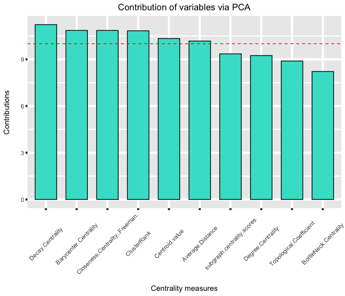

A display of most informative centrality measures based on principal component analysis. The red line indicates the random threshold of contribution. This barplot represents contribution of variable values based on the number of dimensions.

For choosing the number of principal components, we considered cumulative percentage of variance values which are more than 80 as the cut off which can be edited using `cut.off` argument. It returns a plot for visualizing contribution values of the computed centrality measures due to the number of principal components. The `scale.unit` argument gives the ability to whether it should normalize the input or not.

```r
pca_centralities( calc_cent , scale.unit = FALSE )
```

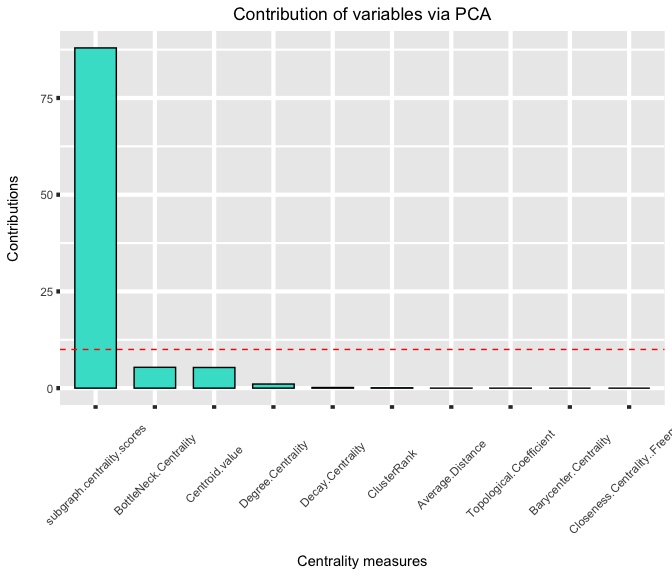

A representation of most informative centrality measures based on principal component analysis between unscaled(not normalized) centrality values.

Another method for distinguishing which centrality measure has more information or in another words has more costs is using (t-SNE) t-Distributed Stochastic Neighbor Embedding analysis(Van Der Maaten 2014). This is a non-linear dimensional reduction algorithm used for high-dimensional data. `tsne_centralities` function applies t-sne on centrality measure values like below:

```r
tsne_centralities( calc_cent, dims = 2, perplexity = 1, scale=TRUE)
```

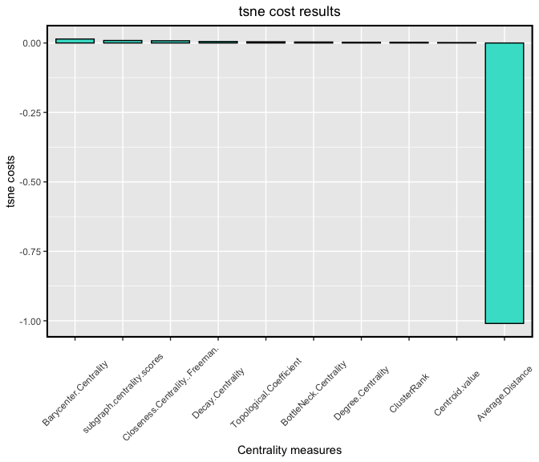

This returns the bar plot of computed cost values of each centrality measure on a plot. In order to access only computed values of PCA and t-sne methods, `summary_pca_centralities` and `tsne_centralities` functions can be helpful.

## 5 visualization of centrality analysis

To visualize the results of network centrality analysis some convenient functions have been developed as it described below.

### 5.1 Graph visualization regarding to the centrality type

After evaluating centrality measures, demonstrating high values of centralities in some nodes gives an overall insight about the network to the researcher. By using `visualize_graph` function, you will be able to illustrate the input graph based on the specified centrality value. If the centrality measure values were computed, `computed.centrality.value` argument is recommended. Otherwise, using `centrality.type` argument, the function will compute centrality based on the input name of centrality type. For practice, we specifies `Degree Centrality`. Here,

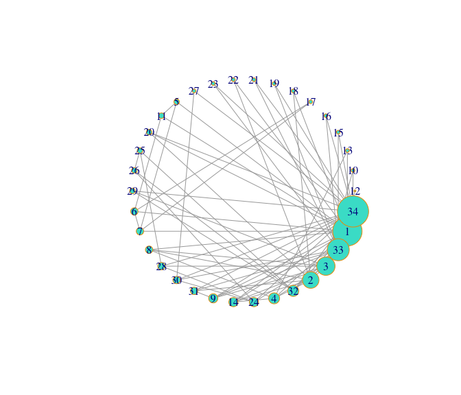

Graph illustration based on centrality measure. The size of nodes represent the degree centrality values.

```r
visualize_graph( zachary , centrality.type="Degree Centrality")
```

### 5.2 Heatmap of centrality measure values

On of the way of complex large network visualizations(more than 100 nodes and 200 edges) is using heat map(Pryke, Mostaghim, and Nazemi 2007). `visualize_heatmap` function demonstrates a heat map plot between the centrality values. The input is a list containing the computed values.

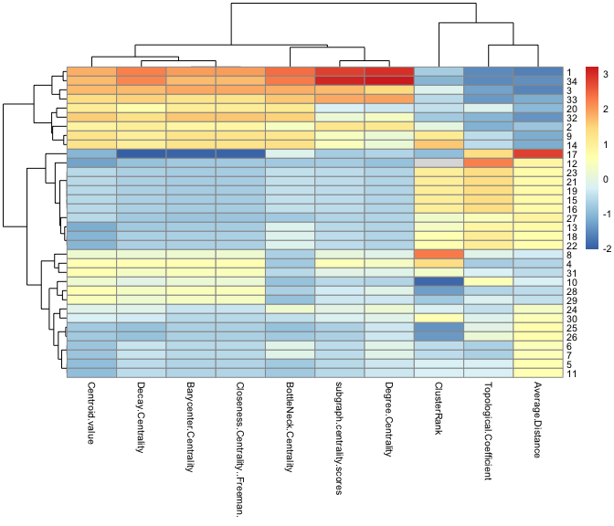

Observed centrality measure heatmap. The colors from blue to red displays scaled centrality values.

```r
visualize_heatmap( calc_cent , scale = TRUE  )
```

### 5.3 Correlation between computed centrality measures

Comprehending pair correlation among centralities is a popular analysis for researchers(Dwyer et al. 2006). In order to that, `visualize_correlations` method is appropriate. In this you are able to specify the type of correlation which you are enthusiastic to obtain.

```r
visualize_correlations(calc_cent,"pearson")
```

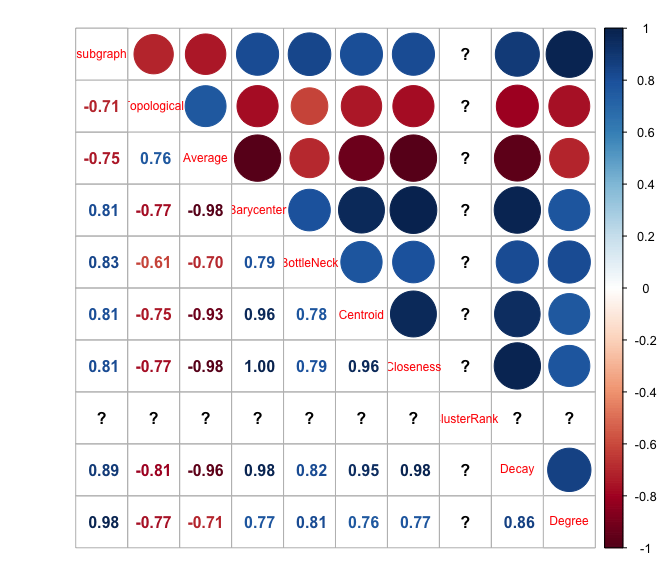

A display of correlation among computed centrality measures. The red to blue highlighted circles represent the top to bottom Pearson correlation coefficients(Benesty et al. 2009) which differ from -1 to 1. The higher the value becomes larger, circles’ sizes get larger too.

### 5.4 Node dendrogram based on a centrality type

In order to visualize a simple clustering across the nodes of a graph based on a specific centrality measure, we can use the `visualize_dendrogram` function. This function draw a dendrogram plot in which colors indicate the clusters.

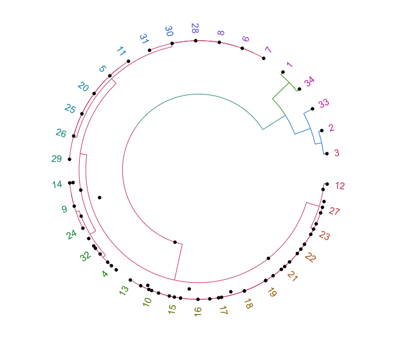

Circular dendrogram plot of vertices based on specified centrality measure. Each color represents a cluster.

```r
visualize_dendrogram(zachary, k=4)
```

### 5.5 Regression across centrality measures

In this package additionally to correlation calculation, ability to apply linear regression for each pair of centralities has been prepared to realize the association between centralities. For visualization, `visualize_association` method is an appropriate function to use:

```
## $linear.regression
##
## Call:
## lm(formula = df[, 2] ~ df[, 1])
##
## Coefficients:
## (Intercept)      df[, 1]
##   1.210e-16   -7.059e-01
##
##
## $visualization
```

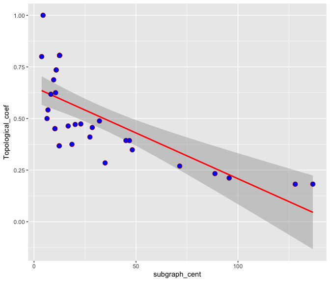

Association plot between two centrality variables. The red line is an indicator of linear regression line among them.

```r
subgraph_cent <- calc_cent[[1]]
Topological_coef <- calc_cent[[2]]

visualize_association(  subgraph_cent , Topological_coef)
```

### 5.6 Pairwise correlation between centrality types

To access the distribution of centrality values and their corresponding pair correlation value, `visualize_pair_correlation` would be helpful. The Pearson correlation(Benesty et al. 2009) has been used for this method.

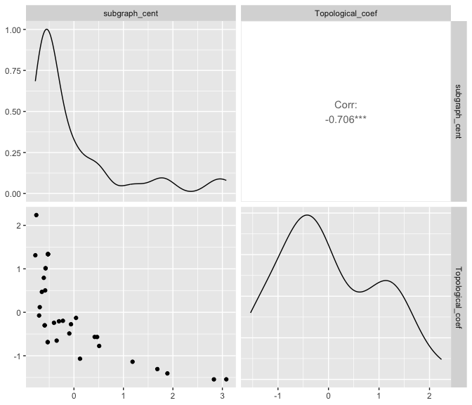

Pairwise Pearson correlation between two centrality values.

```r
visualize_pair_correlation( subgraph_cent , Topological_coef)
```

The result is a scatter plot visualizing correlation values.

# References

Barneh, Farnaz, Mohieddin Jafari, and Mehdi Mirzaie. 2015. “Updates on Drug–Target Network; Facilitating Polypharmacology and Data Integration by Growth of DrugBank Database.” *Briefings in Bioinformatics* 17 (6): 1070–80.

Barret Schloerke, Di Cook, Jason Crowley, and Joseph Larmarange. 2016. “GGally: Extension to ’Ggplot2’. R Package Version 1.3.0.” Journal Article. https://CRAN.R-project.org/package=GGally.

Benesty, Jacob, Jingdong Chen, Yiteng Huang, and Israel Cohen. 2009. “Pearson Correlation Coefficient.” *Noise Reduction in Speech Processing*, 1–4.

Butts, Carter T. 2008. “Network: A Package for Managing Relational Data in r.” Journal Article. *Journal of Statistical Software* 24 (2): 1–36.

Csardi, Gabor, and Tamas Nepusz. 2006. “The Igraph Software Package for Complex Network Research.” Journal Article. *InterJournal, Complex Systems* 1695 (5): 1–9.

CT, Butts. 2007. “Sna: Tools for Social Network Analysis. Version 1.5.” Journal Article.

———. 2008. “Social Network Analysis with Sna. Journal of Statistical Software.” Journal Article, 24(6). https://www.jstatsoft.org/article/view/v024i06.

Data., Butts C (2015). network: Classes for Relational. 2015. “Network: Classes for Relational Data. The Statnet Project (Https://Statnet.org). R Package Version 1.13.0.” Journal Article.

Dwyer, Tim, Seok-Hee Hong, Dirk Koschützki, Falk Schreiber, and Kai Xu. 2006. “Visual Analysis of Network Centralities.” In *Proceedings of the 2006 Asia-Pacific Symposium on Information Visualisation-Volume 60*, 189–97. Australian Computer Society, Inc.

Felleman, Daniel J, and David C Van Essen. 1991. “Distributed Hierarchical Processing in the Primate Cerebral Cortex.” Journal Article. *Cerebral Cortex* 1 (1): 1–47.

Galili, Tal. 2015. “Dendextend: An r Package for Visualizing, Adjusting and Comparing Trees of Hierarchical Clustering.” Journal Article. *Bioinformatics*, btv428.

Garnier, Simon. 2017. *Viridis: Default Color Maps from ’Matplotlib’*. https://CRAN.R-project.org/package=viridis.

Gu, Zuguang, Lei Gu, Roland Eils, Matthias Schlesner, and Benedikt Brors. 2014. “Circlize Implements and Enhances Circular Visualization in r.” Journal Article. *Bioinformatics*, btu393.

Husson, F, S Lê, and J Pages. 2010. “Exploratory Multivariate Analysis by Example Using r, Volume 20105550 of Chapman & Hall/CRC Computer Science & Data Analysis.” Journal Article. *CRC Press* 30: 101–2.

Jalili, Mahdi, Ali Salehzadeh-Yazdi, Yazdan Asgari, Seyed Shahriar Arab, Marjan Yaghmaie, Ardeshir Ghavamzadeh, and Kamran Alimoghaddam. 2015. “CentiServer: A Comprehensive Resource, Web-Based Application and r Package for Centrality Analysis.” Journal Article. *PloS One* 10 (11): e0143111.

Kassambara. n.d. “A. Factoextra: Visualization of the Outputs of a Multivariate Analysis. R Package Version 1.0. 1. 2015.” Journal Article.

Kolde, Raivo. 2015. “Pheatmap: Pretty Heatmaps. R Package Version 1.0. 2.”

KONECT. October 2016. “Kangaroo Network Dataset.” Journal Article, October 2016.

———. October 2016. “Rhesus Network Dataset.” Journal Article, October 2016.

Krijthe, J. 2015. “Rtsne: T-Distributed Stochastic Neighbor Embedding Using Barnes-Hut Implementation.” *R Package Version 0.10, URL Https://Cran.r-Project.org/Web/Packages/Rtsne/Index.html*.

Newman, Mark. 2010. *Networks*. Oxford University Press.

Pryke, Andy, Sanaz Mostaghim, and Alireza Nazemi. 2007. “Heatmap Visualization of Population Based Multi Objective Algorithms.” In *Evolutionary Multi-Criterion Optimization*, 361–75. Springer.

Rinker, Tyler W. 2015. *qdapTools: Tools to Accompany the Qdap Package*. Buffalo, New York: University at Buffalo/SUNY. https://github.com/trinker/qdapTools.

Sebastien Le, Francois Husson, Julie Josse. 2008. “FactoMineR: An r Package for Multivariate Analysis. Journal of Statistical Software.” Journal Article, no. 25(1): 1–18.

Simko, Taiyun Wei, and Viliam. 2016. “Corrplot: Visualization of a Correlation Matrix. R Package Version 0.77.” Journal Article.

Van Der Maaten, Laurens. 2014. “Accelerating t-SNE Using Tree-Based Algorithms.” *Journal of Machine Learning Research* 15 (1): 3221–45.

Wickham, Hadley. 2011. “The Split-Apply-Combine Strategy for Data Analysis.” *Journal of Statistical Software* 40 (1): 1–29. https://www.jstatsoft.org/article/view/v040i01.

Zachary, Wayne W. 1977. “An Information Flow Model for Conflict and Fission in Small Groups.” Journal Article. *Journal of Anthropological Research* 33 (4): 452–73.